# Project 1

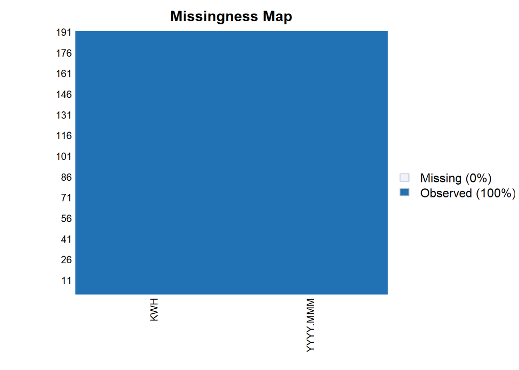

```r
missmap(df.power)
```

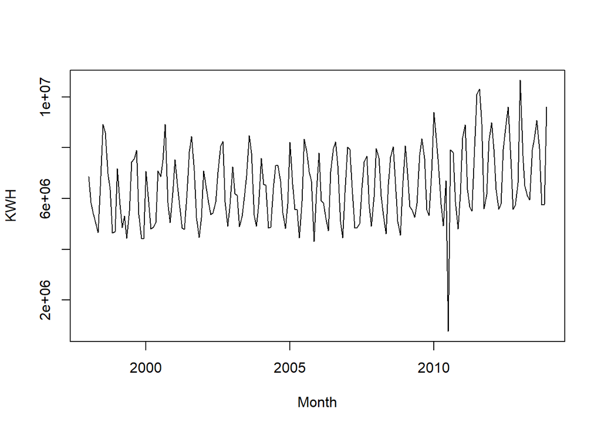

```r
plot(df.power, type = 'l', xlab = 'Month')
```

## Time Series Analysis

To get started, we’ll need to take our power dataset and create a time series object for using the `ts()` function. We’ll specify that the start date for the time series is January 1st, 1998, and the frequency is monthly.

```r
ts.power <- ts(df.power$KWH, start = c(1998, 1, 1), frequency = 12)
```

### Time Series Power

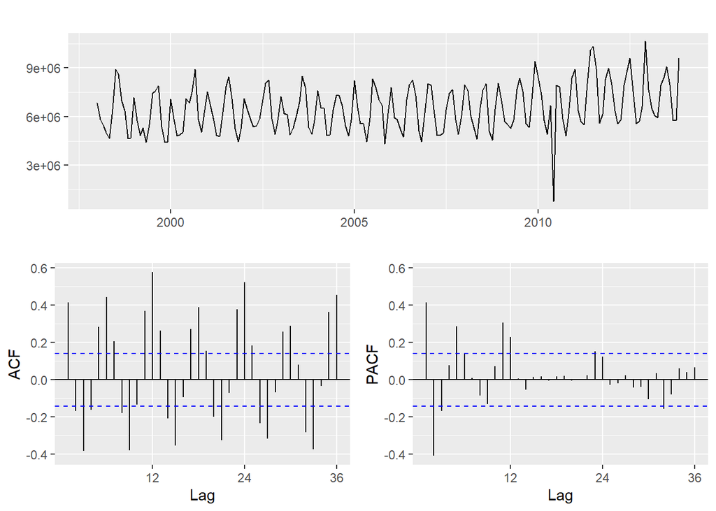

```r
ggtsdisplay(ts.power, points = FALSE)
```

```r
lam.power <- BoxCox.lambda(ts.power)
lam.power
```

```
## [1] 0.06361748
```

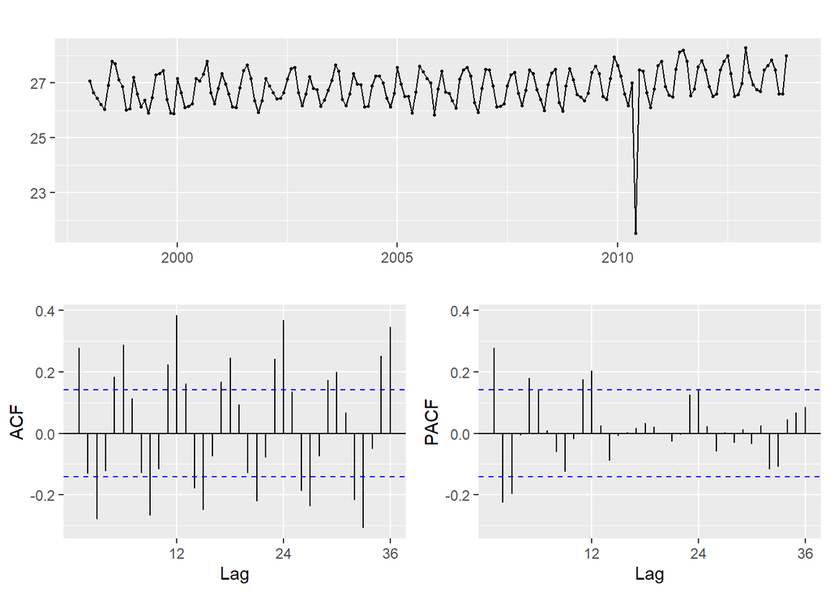

```r
ggtsdisplay(BoxCox(ts.power, lam.power))
```

We can see that our lambda resulted in 0.063.

#### Holt - Power

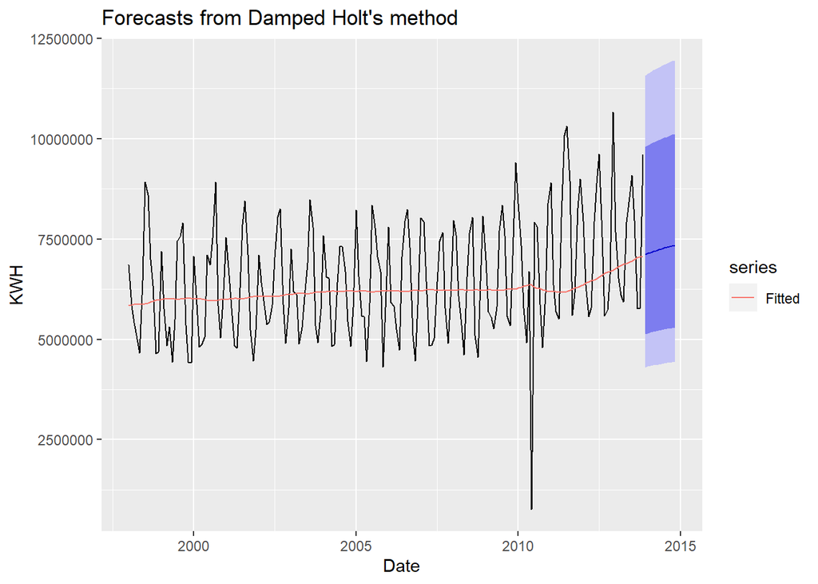

```r
ht.power <- holt(ts.power, lambda = lam.power, h = 12, damped = TRUE)
autoplot(ht.power) +
  autolayer(fitted(ht.power), series="Fitted") +
  ylab("KWH") + xlab("Date")
```

```r
accuracy(ht.power)
```

```
##                    ME    RMSE     MAE       MPE     MAPE     MASE      ACF1
## Training set 291263.5 1444322 1167541 -2.948901 20.90064 1.569069 0.3893446
```

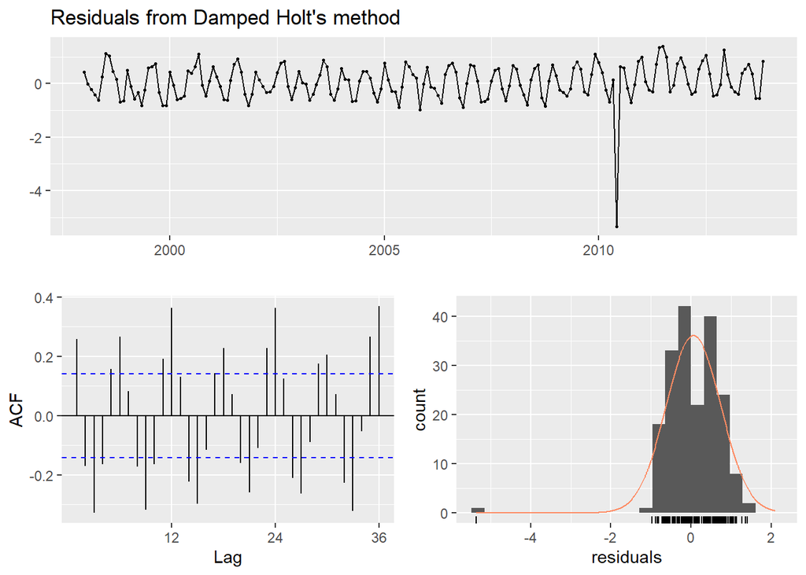

```
##
##  Ljung-Box test
##
## data:  Residuals from Damped Holt's method
## Q* = 246.7, df = 19, p-value < 2.2e-16
##
## Model df: 5.   Total lags used: 24
```

```r
checkresiduals(ht.power)
```

Looking at our residuals, they look very similar to pre-transformation, but their actual values have changes. We see similar trend with the ACF plot. We do have a RMSE of 1444322 and a significant p-value less that 0.05 at 2.2e-16.

#### ARIMA - Power

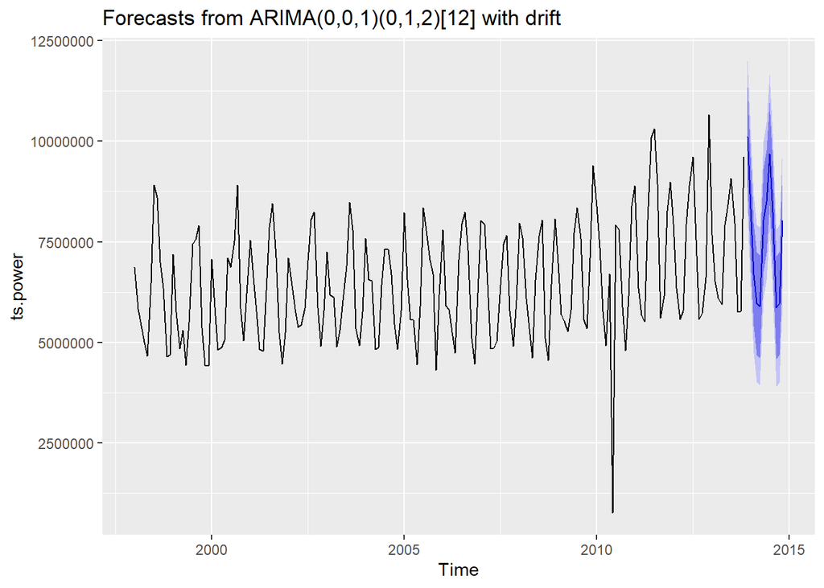

```r
ar.power <- auto.arima(ts.power)
autoplot(forecast(ar.power, h = 12))
```

```r
accuracy(ar.power)
```

```
##                     ME     RMSE    MAE       MPE    MAPE      MASE         ACF1
## Training set -10349.99 927823.9 576140 -5.029934 12.4629 0.7742797 -0.002808329
```

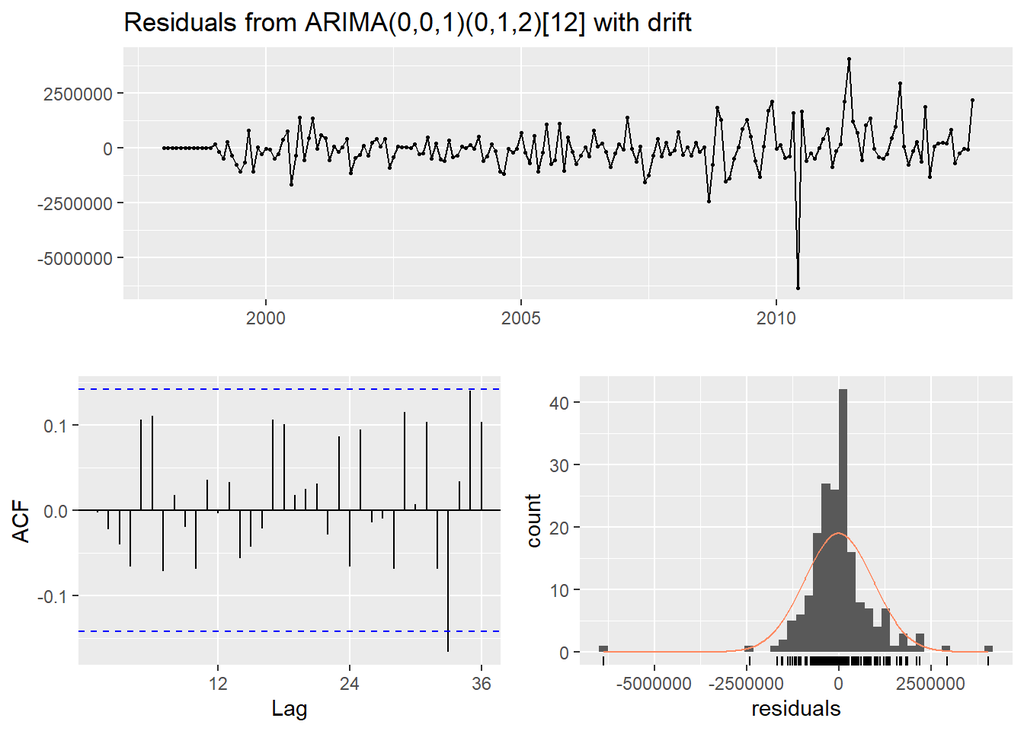

```
##
##  Ljung-Box test
##
## data:  Residuals from ARIMA(0,0,1)(0,1,2)[12] with drift
## Q* = 17.494, df = 20, p-value = 0.6207
##
## Model df: 4.   Total lags used: 24
```

```r
checkresiduals(ar.power)
```

Looking at our residuals, they look very similar to pre-transformation, but have a greater range than compared to the Holt model’s residuals. For the ACF plot, we see that our lags are they decrease over time. We do have a RMSE of 927823.9 and a p-value greater than 0.05 at .6207.

#### Forecast Comparison - Power

Now we can compare the two forecasts

```r
comparison <- data.frame(rbind(accuracy(ht.power), accuracy(ar.power)))
rownames(comparison) <- c('Holt', 'ARIMA')
comparison
```

```
##              ME      RMSE     MAE       MPE     MAPE      MASE         ACF1
## Holt  291263.48 1444322.4 1167541 -2.948901 20.90064 1.5690689  0.389344608
## ARIMA -10349.99  927823.9  576140 -5.029934 12.46290 0.7742797 -0.002808329
```

As we compare the two methods of forecasting, we can see that the ARIMA model has a lower RMSE indicating a better fit. We’ll make sure to use the ARIMA model for our forecast export.

```r
for.power <- data.frame(forecast(ar.power, h = 1))
write_csv(remove_rownames(for.power), 'Forecast_Power.csv')
```